# R Notebook

#DDG2P 데이터

```r
library(dplyr)
library(ggplot2)
library(tidyverse)
library(readr)
library(ggrepel)
library(cowplot)
```

## 주제 각 gene에 대한 developmental disorder 발생 빈도와 종류 및 pLI 분포

`pLI`의 정의는 The probability of being loss-of-function intolerant (intolerant of both heterozygous and homozygous loss-of-function variants) 입니다.

LOF(loss-of-function)을 견디지 못하는, 즉 해당 gene에 *LOF가 발생했을 때* *정상적으로 작동하지 않을 확률*을 말합니다.

gene 하나 하나 보기에는 gene 수가 너무 많은 관계로, developmental disorder 발생 빈도가 높은 gene을 선별적으로 추출했습니다.

gene의 pLI score과 developmental disorder 발생 빈도를 비교합니다. pLI score과 developmental disorder 발생 빈도 사이에 관계가 있음을 가설로 세웁니다. disorder 발생 빈도가 높은 gene일수록 LOF에 취약할 것이라 추측합니다.

한 번 알아보도록 하겠습니다.

## 설명

```r
#DDG2P 데이터를 `DDG`에 저장합니다.
DDG<- read.delim("DDG2P_24_9_2019.with_pLI.txt", sep='\t', header = T,)
```

```r
#DDG에서 developmental disorder 발생 빈도가 5를 초과하는 gene을 선별합니다.
gg <- DDG %>% select(gene.symbol) %>% group_by(gene.symbol) %>% dplyr::count() %>% filter(n>5) %>% select(gene.symbol) %>% .$gene.symbol
```

```r
#gene별로 developmental disorder 발생 빈도와 pLI를 비교합니다.
#대체로 developmental disorder 발생 빈도가 높은 gene은 pLI 또한 1에 가깝다는 것을 알 수 있습니다.
p1 <- DDG[DDG$gene.symbol %in% gg, ] %>% select(gene.symbol, disease.name, pLI) %>% group_by(gene.symbol, pLI) %>% dplyr::count() %>%
  ggplot(aes(n, pLI)) +
  geom_text_repel(aes(label = gene.symbol), show.legend = FALSE, size = 3, box.padding = 0.6) +
  geom_point(size = 1) +
  coord_fixed(ratio = 10) +
  coord_flip() +
  xlab("Developmental Disorder Frequency") +
  ylab("pLI (Probability of being loss-of-function intolerant)") +
  xlim(0, 11) +
  ggtitle("Relationship between DD Frequency and pLI \n (Genes with DD Frequency>5)") +
  theme(plot.title = element_text(size = 18, face = "bold", hjust = 0.5))
```

```r
#가장 많은 gene과 연관된 developmental disorder 종류
disease_freq <- DDG %>% select(disease.name) %>% group_by(disease.name) %>% dplyr::count()
top_six_freq <- disease_freq[order(-disease_freq$n) ,] %>% head()
##플로팅
p2_1 <- top_six_freq %>%
  ggplot(aes(reorder(disease.name, n), n)) +
  geom_col(fill = "#e88eca") +
  ylab("Occurrence Frequency in genes") +
  xlab("Developmental Disorder") +
  geom_text(aes(label = n), vjust = 0.5, hjust = 0.5, color = "black", size = 6) +
  coord_fixed(ratio = 1/10) +
  coord_flip() +
  scale_x_discrete(labels = c("AUTISM", "LEIGH SYNDROME", "ZELLWEGER SYNDROME", "EPILEPTIC
  ENCEPHALOPATHY", "INTELLECTUAL
  DISABILITY", "AUTOSOMAL RECESSIVE
                     MENTAL RETARDATION")) +
  ggtitle("Top six Most Frequent Developmental Disorders \n (in all genes)") +
  theme(plot.title = element_text(size = 17, face = "bold"))
```

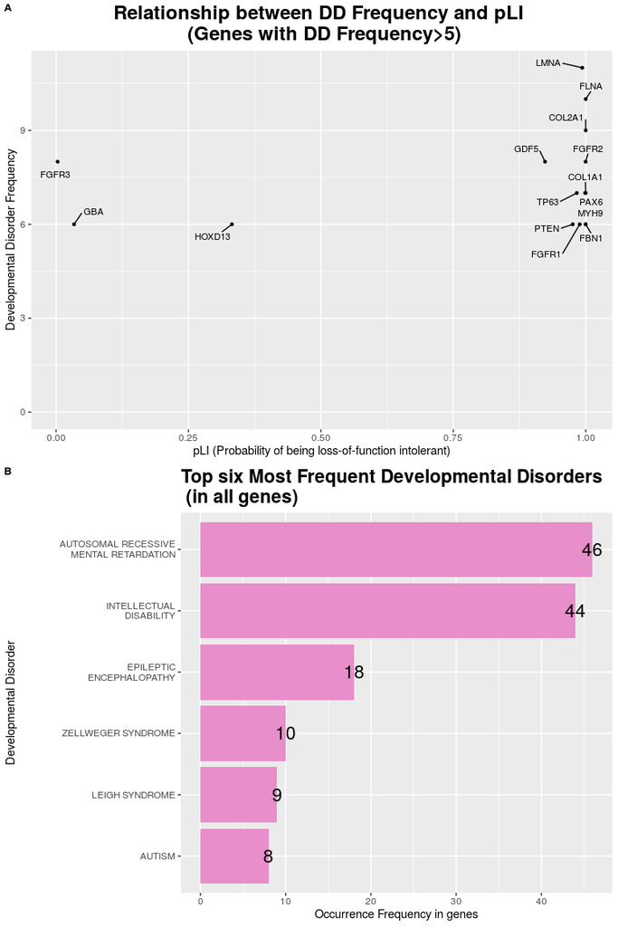

```r
#플롯 합치기
great <- plot_grid(p1, p2_1, labels = c('A', 'B'), label_size = 10, ncol = 1)




#높이를 길게 저장했습니다.
ggsave("DDD2P.DiseaseFreqWithpLI.20191017.jpg", great, height = 12, width = 8)




great
```

# **피드백 반영**

### (1)plot A에서 어떤 label이 어떤 point에 해당하는지 보기 어려움.

어떤 label에 어떤 point에 해당하는지 보다 명확히 하기 위해, label간의 거리를 벌렸다. label size를 줄이고, point size 또한 줄였다.

**label과 point의 색을 같게 하여 그 관계를 명확히 함과 동시에 color blind friendly하며 서로 구분이 되는 15개의 point 색을 지정하는 것**은 label과 point가 또렷하게 보이지 않는 색이 있어 적용하지 않았다.

**범례를 넣는 것**은, gene symbol이 15개로 너무 많아 가독성이 떨어진다고 판단하여 적용하지 않았다.

### (2)plot A에서, 어떤 기준으로 gene을 선택했는지에 대한 정보 부족.

plot A의 title에 ‘(Genes with DD Frequency>5)’ 를 추가하여, DD Frequency가 5보다 큰 gene을 선별했음을 명시했다.

### (3)plot B에서, frequency에 해당하는 actual number 정보 부족.

geom_text(aes(label = n))를 이용해 actual number를 기입했다.

### (4)plot A, B 모두 title 크기 키우기.

theme()의 plot.title을 이용해 제목의 크기를 키우고 굵게 표현했다.